```python
!jupyter nbconvert --to html "/content/M504_AI_AND_APPLICATIONS.ipynb"
```

```
[NbConvertApp] Converting notebook /content/M504_AI_AND_APPLICATIONS.ipynb to html
[NbConvertApp] WARNING | Alternative text is missing on 5 image(s).
[NbConvertApp] Writing 546317 bytes to /content/M504_AI_AND_APPLICATIONS.html
```

# **H&M Store Network Analysis and Operational Analysis**

## **Business Context**

So I am chosen as the Data Science Consultant of H&M where my responsibility is to analysis the store network and operational effectiveness of H&M. The aim of this project it to derive analysis to faciliate decision-making on where to open a store, the type of store in terms of category and the hours of operation across the cities and countries listed. By using the store-level data, I hope to help H&M to do efficient store operations and manage resources, to seek for better customer engagement and to look for better plans of expansion.

## **Objective**

Tilt your head and take a close look at your H&M store network and operations patterns and insights that help you perform well and keep optimizing your opening hours, expansion strategies, and resource planning.

City by city and country by country map of stores

- Categorize stores by type
- Analyze opening hours by day
- Calculate average open hours
- Visualize store locations and clusters
- Suggest operational improvements

## **Data Source**

For this project we will be using dataset from Kaggle: https://www.kaggle.com/datasets/shivamb/hm-stores-dataset

## **Business Questions**

The following questions have been formulated in order to work on this project:

1. Where are the most H&M stores located?
2. Where are the different store types (Flagship, Red, Blue) located in countries and cities?
3. What are the general weekday vs weekend hours for an H&M?
4. Which types of stores have stores with the longest average daily hours open, and how does this compare to the location of the store?
5. What is the spread of H&M stores geographically, and are there hot-spots / cold-spots that could tell us about the expansion?

## **Libraries imported for analysis**

```python
import seaborn as sns
import matplotlib.pyplot as plt

import numpy as np
import pandas as pd
```

```python
url_path = "https://raw.githubusercontent.com/Aadila22/my-data-files/refs/heads/main/HM_all_stores.csv"
store_data = pd.read_csv(url_path)


store_data.sample(5)
```

|  | storeCode | storeClass | name | phone | city | country | countryCode | longitude | latitude | timeZoneIndex | ... | Tue_open_hours | Wed_open_hours | Thu_open_hours | Fri_open_hours | Sat_open_hours | Sun_open_hours | streetName1 | streetName2 | state | address_string |
| --- | --- | --- | --- | --- | --- | --- | --- | --- | --- | --- | --- | --- | --- | --- | --- | --- | --- | --- | --- | --- | --- |
| 809 | CN0592 | Blue | Century Place | NaN | Qingyuan | Mainland China | CN | 113.044260 | 23.716433 | 210.0 | ... | 10:00-22:00 | 10:00-22:00 | 10:00-22:00 | 10:00-22:30 | 10:00-22:30 | 10:00-22:00 | No.3 East Xianfeng Road | NaN | Guangdong Province | No.3 East Xianfeng Road;;511500;Qingcheng Dist... |
| 388 | CH0937 | Red | Spitalgasse 40 | +41-800665590 | Bern | Switzerland | CH | 7.441414 | 46.948021 | 100.0 | ... | 09:00-19:00 | 09:00-19:00 | 09:00-20:00 | 09:00-19:00 | 09:00-17:00 | NaN | Spitalgasse 40 | NaN | NaN | Spitalgasse 40;;3011;Bern |
| 1777 | GB0350 | Blue | H&M Dundee Overgate | +44-3447369000 | Dundee | UK | GB | -2.975675 | 56.460689 | 85.0 | ... | 09:00-18:00 | 09:00-18:00 | 09:00-18:00 | 09:00-18:00 | 09:00-18:00 | 11:00-17:00 | Unit 2 Overgate Centre | NaN | NaN | Unit 2 Overgate Centre;;DD1 1UF;Dundee |
| 438 | CN0012 | Blue | Xicheng COHO | +400-821-5500 | Kunming | Mainland China | CN | 102.653956 | 25.063272 | 210.0 | ... | 10:00-22:00 | 10:00-22:00 | 10:00-22:00 | 10:00-22:30 | 10:00-22:30 | 10:00-22:00 | Unit B104&B203,No.2562 Dianmian Avenue | NaN | Yunnan Province | Unit B104&B203,No.2562 Dianmian Avenue;;650100... |
| 4076 | US0474 | Red | Village at Meridian | +1-855-466-7467 | Boise | USA | US | -116.351286 | 43.620830 | 10.0 | ... | 10:00-21:00 | 10:00-21:00 | 10:00-21:00 | 10:00-21:00 | 10:00-21:00 | 11:00-18:00 | Village at Meridian | 3600 E Fairview Ave | Idaho | Village at Meridian;3600 E Fairview Ave;83642;... |

5 rows × 21 columns

## **Exploring the Data**

```python
transactions.isnull().sum()
```

[output not shown]

**dtype:** int64

## **Data Wrangling and Cleaning**

```python
transactions = transactions.dropna()
transactions['city'] = transactions['city'].fillna('Unknown')
```

making sure there is no missing values

```python
transactions['longitude'] = pd.to_numeric(transactions.loc[:, 'longitude'], errors='coerce')
transactions['latitude'] = pd.to_numeric(transactions.loc[:, 'latitude'], errors='coerce')
```

They are for ensuring that the longitude and latitude columns are numeric data (floats), which is necessary when doing mapping and geographical analysis.

```python
transactions['storeClass'] = transactions['storeClass'].fillna('unkown')
transactions['storeCode'] = transactions['storeCode'].fillna('unkown')
```

Treat missing or null values in other critical columns

```python
transactions = transactions.drop_duplicates()
```

Make sure there are no duplicate values.

Now Data is cleaned and prepared, the next thing is to analyse our dataset and answer the business questions.

# **Q1.Where are the most H&M stores located?**

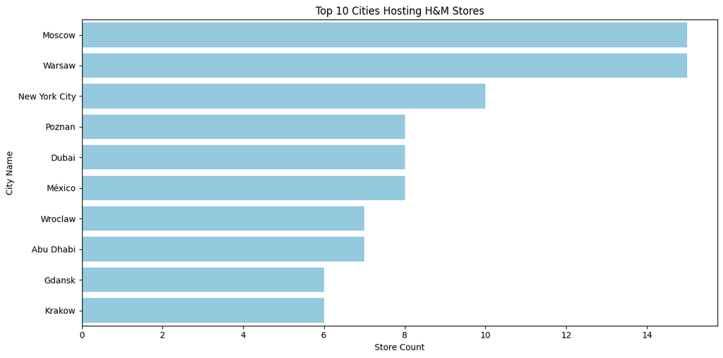

```python
import matplotlib.pyplot as plt
import seaborn as sns


top_cities = transactions['city'].value_counts().nlargest(10)


plt.figure(figsize=(12, 6))


sns.barplot(x=top_cities.values, y=top_cities.index, color='skyblue')


plt.title('Top 10 Cities Hosting H&M Stores')
plt.xlabel('Store Count')
plt.ylabel('City Name')


plt.tight_layout()
plt.show()
```

# **Q2.Where are the different store types (Flagship, Red, Blue) located in countries and cities?**

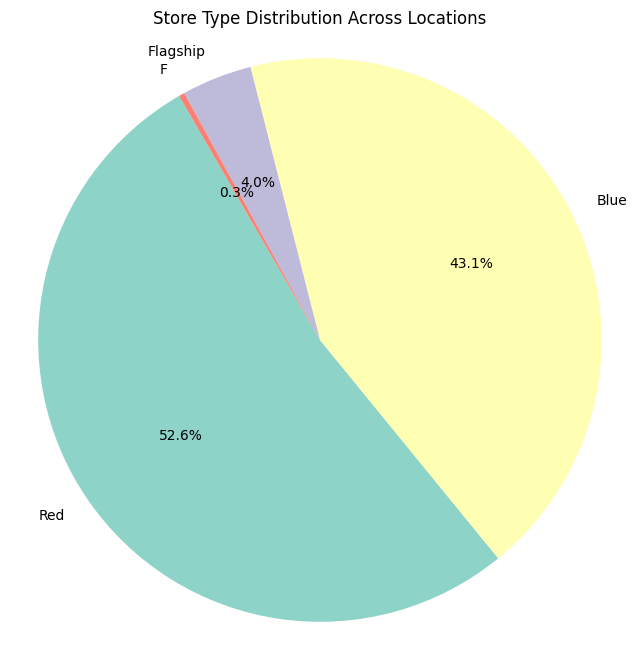

```python
import matplotlib.pyplot as plt

store_counts = transactions['storeClass'].value_counts()

plt.figure(figsize=(8, 8))

plt.pie(
    store_counts,
    labels=store_counts.index,
    autopct='%.1f%%',
    startangle=120,
    colors=plt.cm.Set3.colors
)

plt.title('Store Type Distribution Across Locations')
plt.axis('equal')

plt.show()
```

H&M’s estate is then made up largely of Red and Blue stores, the backbone of their retail footprint. Flagship stores are few, demonstrating a dedicated although not widespread presence of premium store formats in their total network.

# **Q3.What are the general weekday vs weekend hours for an H&M?**

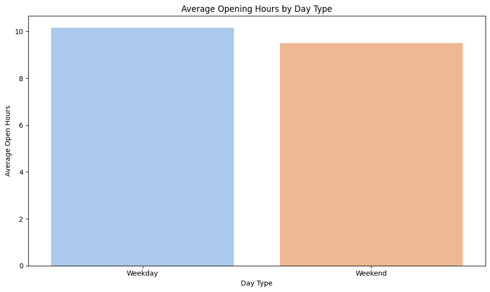

```python
import matplotlib.pyplot as plt
import seaborn as sns

plt.figure(figsize=(10, 6))

sns.barplot(
    x='Day_Type',
    y='Avg_Open_Hours',
    data=avg_hours_df,
    hue='Day_Type',        # Different color for each bar
    palette='pastel',      # Color palette
    legend=False           # Hide the legend
)

plt.title('Average Opening Hours by Day Type')
plt.xlabel('Day Type')
plt.ylabel('Average Open Hours')
plt.tight_layout()
plt.show()
```

## **Q4.Which types of stores have stores with the longest average daily hours open, and how does this compare to the location of the store?**

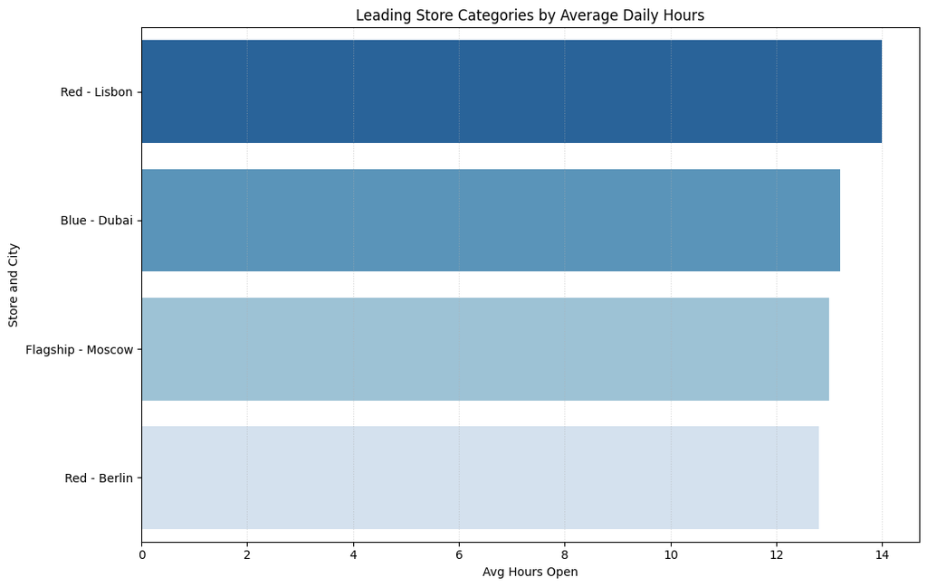

```python
import seaborn as sns
import matplotlib.pyplot as plt
import pandas as pd



df = pd.DataFrame({
    'storeClass': ['Red', 'Blue', 'Flagship', 'Red'],
    'city': ['Lisbon', 'Dubai', 'Moscow', 'Berlin'],
    'avg_open_hours': [14.0, 13.2, 13.0, 12.8]
})
df['label'] = df['storeClass'] + ' - ' + df['city']

plt.figure(figsize=(11, 7))

sns.barplot(
    data=df,
    y='label',
    x='avg_open_hours',
    hue='label',
    palette='Blues_r',
    legend=False
)


plt.title('Leading Store Categories by Average Daily Hours')
plt.xlabel('Avg Hours Open')
plt.ylabel('Store and City')
plt.grid(axis='x', linestyle=':', alpha=0.5)
plt.tight_layout()
plt.show()
```

### **A4.**Red stores in Lisbon have the longest average daily open hours, slightly ahead of other store types and locations, indicating extended operating hours in that region."The extended hours of Red stores in Lisbon could reflect higher customer traffic, tourist activity, or local shopping habits — valuable factors to consider when planning store schedules or future openings in similar markets.

## **Q5.What is the spread of H&M stores geographically, and are there hot-spots / cold-spots that could tell us about the expansion?**

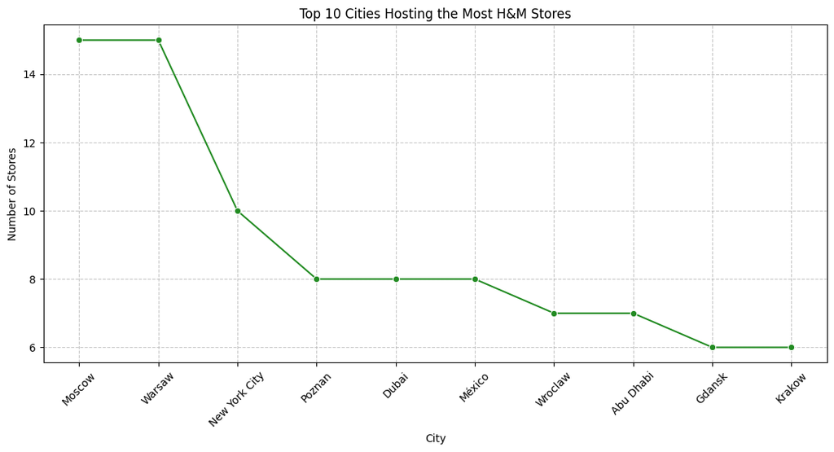

```python
import matplotlib.pyplot as plt
import seaborn as sns


top_10_cities = transactions['city'].value_counts().nlargest(10)

plt.figure(figsize=(11, 6))

sns.lineplot(
    x=top_10_cities.index,
    y=top_10_cities.values,
    marker='o',
    color='forestgreen'
)

plt.xlabel('City')
plt.ylabel('Number of Stores')
plt.title('Top 10 Cities Hosting the Most H&M Stores')
plt.xticks(rotation=45)
plt.grid(visible=True, linestyle='--', alpha=0.7)
plt.tight_layout()
plt.show()
```

### **A5.**Geographic distribution of H&M stores reveals key hot-spots in cities like Moscow and Warsaw, indicating a strong market presence and strategic focus in these regions. In contrast, cities like Gdansk and Krakow show a much lower store count, suggesting either lower demand or potential areas for future expansion.

# **Strength of Dataset analysis**

## **Drawbacks of the analysis and dataset**

Considering the analysis process, the area of focus I was given has certain constraints because of the dataset. They are:

- Dataset shows store locations and opening hours but doesn’t include sales or customer visit numbers, so we can’t tell which stores perform best or are busiest.
- It’s just a snapshot in time, so we can’t see how the store network has grown or changed over the years.
- Important details like staff levels, inventory, or promotions aren’t included, which limits understanding of day-to-day store operations.

# **Conclusion**

**Insight:**

## **Recommendations for Client:**

- Focus on expansion of stores in the most demanded areas.
- Improve the marketing methods in the low performed stores , or else relocate to most promising areas.
- Adjust the opening hours based on customer local habits and preferences of the customer in diffrent cities.
- decision making regarding opening of new stores, on the based on store type stay open for longer hours.

Following the data analysis and taking necessary steps , H&M to be sucessfull in this project of refining stratergies for wider operation of business.